# Learning guarantees for finite hypothesis sets

谷口友哉

2020-10-20

## Motivation

- 事例から学ぶアルゴリズムを設計・解析する際に、いくつかの基本的な疑問 (計算学習問題) が生じる
  - 効率的に学べるものは何か？
  - 本質的に学びにくいものは何か？
  - 学習の一般的なモデルはあるのか？
- Probably Approxably Correct (PAC)学習のフレームワークを導入することで、これらの疑問を形式化し、対処することから始める

## What is the PAC framework?

近似解を達成するために必要なサンプル点の数、サンプルの複雑さ、学習アルゴリズムの時間と空間の複雑さの観点から、学習可能な概念のクラスを定義するのに役立つ（これは概念の計算表現のコストに依存する）

最初にPACフレームワークを説明・例示し、使用される仮説集合が学習する概念を含む一貫性のあるケースと一貫性のないケースの両方で、使用される仮説集合が有限である場合に、このフレームワーク内のいくつかの一般的な学習保証を提示する

## Definitions and Notation

- $\mathcal{X}$ : すべての確からしい例orインスタンス(実例)の集合。**入力空間**とも呼ばれる
  - 例：身長と体重を特徴量とするすべての男性と女性の集合
- $\mathcal{Y}$ : すべての確からしいラベルorターゲット値の集合。ここでは$\mathcal{Y} = \{0, 1\}$に限定(2値分類)
- $target \;concept \; \mathcal{c}:\;X \rightarrow Y$ : $\mathcal{X}$ から $\mathcal{Y}$ への写像。日本語訳は「ターゲット概念」。$\mathcal{Y} = \{0, 1\}$なので、$\mathcal{c}$ は値1を取る$\mathcal{X}$の部分集合と識別できる
- $concept \; class\; \mathcal{C}$ : ターゲット概念の集合
- $target \;distribution; \mathcal{D}$ : $\mathcal{X}$上のfixed 確率分布(パラメータが変動しない？)。training and test examples は$\mathcal{D}$から抽出される。
- $S = (x_1,_\cdots,x_m)$ : training sample (訓練標本)
- $concept \;hypothesis \;sets \;\mathcal{H}$ : 概念仮説集合 $\mathcal{H}$。必ずしも概念集合$\mathcal{C}$と一致しない。
  - 例:全ての線形分類器の集合(線形判別分析、SVMなど)
- 学習アルゴリズム : 訓練標本$S$を受け取り、ターゲット概念$c$に近似する仮説集合$\mathcal{H}$から仮説$h_S$を選択

### What is the task?

- ラベル付けされた標本$S$を用いて、概念$c$に関して一般化誤差が小さい仮説$h∈\mathcal{H}$を選択すること

## Errors

### Definition 2.1 (Generalization error)

ターゲット概念$c\in \mathcal{C}$とターゲット分布$\mathcal{D}$が与えられたときの、仮説$h \in \mathcal{H}$の汎化誤差orリスクは次のように定義される。ここで$1_{\omega}$はイベント$\omega$の指示関数。

$$R(h) = Pr_{x \sim \mathcal{D}}[h(x) \neq c(x)] = \mathbb{E}_{x \sim \mathcal{D}}[1_{h(x) \neq c(x)}] \tag{2.1}$$

- この定義と他の関連する定義のために、関数$\mathcal{H}$とターゲット概念$c$は測定可能でなければならない。
- 仮説の汎化誤差は、分布$\mathcal{D}$とターゲット概念$c$の両方が未知であるため、学習者が直接知ることはできない。
- しかし、学習者はラベル付けされた標本$S$上で仮説の**経験誤差**を測定することができる。

### Definition 2.2 (Empirical error)

仮説$h \in \mathcal{H}$、ターゲット概念$c\in \mathcal{C}$、標本$S = (x1, ... , xm)$が与えられると、仮説$h$の経験誤差または経験リスクは以下で定義される。

$$\hat{R_S}(h) = \frac{1}{m}\sum^{m}_{i = 1}1_{h(x) \neq c(x)} \tag{2.2}$$

- $h \in \mathcal{H}$の経験誤差は標本$S$における$h$の平均誤差
- 一般化誤差は分布$D$に基づくその期待誤差
- i.i.d.標本$S$に基づく経験誤差の期待値は汎化誤差に等しい (経験誤差は汎化誤差の不偏推定量)

$$\mathbb{E}_{S \sim \mathcal{D}^m}[\hat{R_S}(h)] = R(h) \tag{2.3}$$

### proof

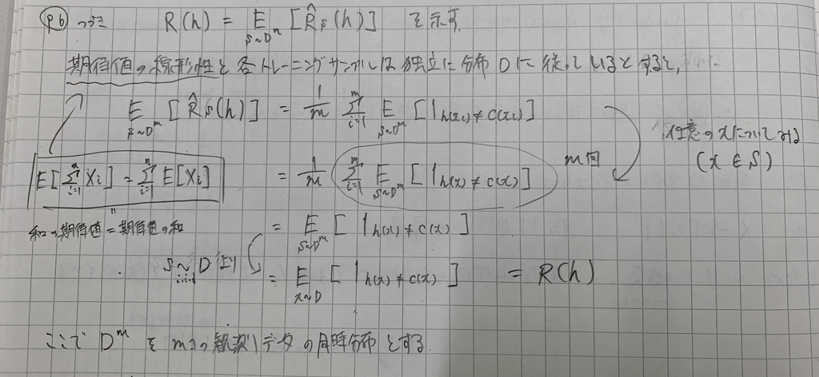

## PAC model

- PAC学習 : Probably Approxably Correct Learning.「確率的におおよそ正しい学習」と訳される

### Definition 2.3 (PAC-learning)

- 以下のような学習アルゴリズム$\mathcal{A}$が存在するとき、概念クラス$\mathcal{C}$は**PAC学習可能(PAC-learnable)**である
  - 固定多項式に対する大きさ$m = poly(1/\epsilon, 1/\delta)$の標本$S$
  - 任意のターゲット概念$c \in \mathcal{C}$,$\epsilon > 0$,$\delta > 0$およびすべての分布$\mathcal{D}$について、

$$Pr_{S \sim \mathcal{D}^m}[R(h_S) \leq \epsilon] \geq 1 - \delta \tag{2.4}$$

### Remarks

- PAC フレームワークはdistribution-free モデル (分布の仮定なし)
- 誤差を定義するために使用される学習サンプルとテスト例は、同一の分布$\mathcal{D}$に従う
- パラメータ$\delta > 0$は信頼度$1 - \delta$を、$\epsilon > 0$は精度$1 - \epsilon$を求めるために使用
- 概念クラス$\mathcal{C}$はアルゴリズムにとって既知であるが、ターゲット概念$c \in \mathcal{C}$は未知であることに注意

## Example (Rectangles Learning)

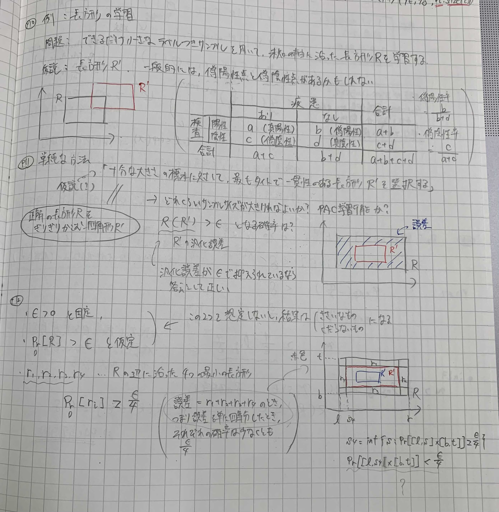

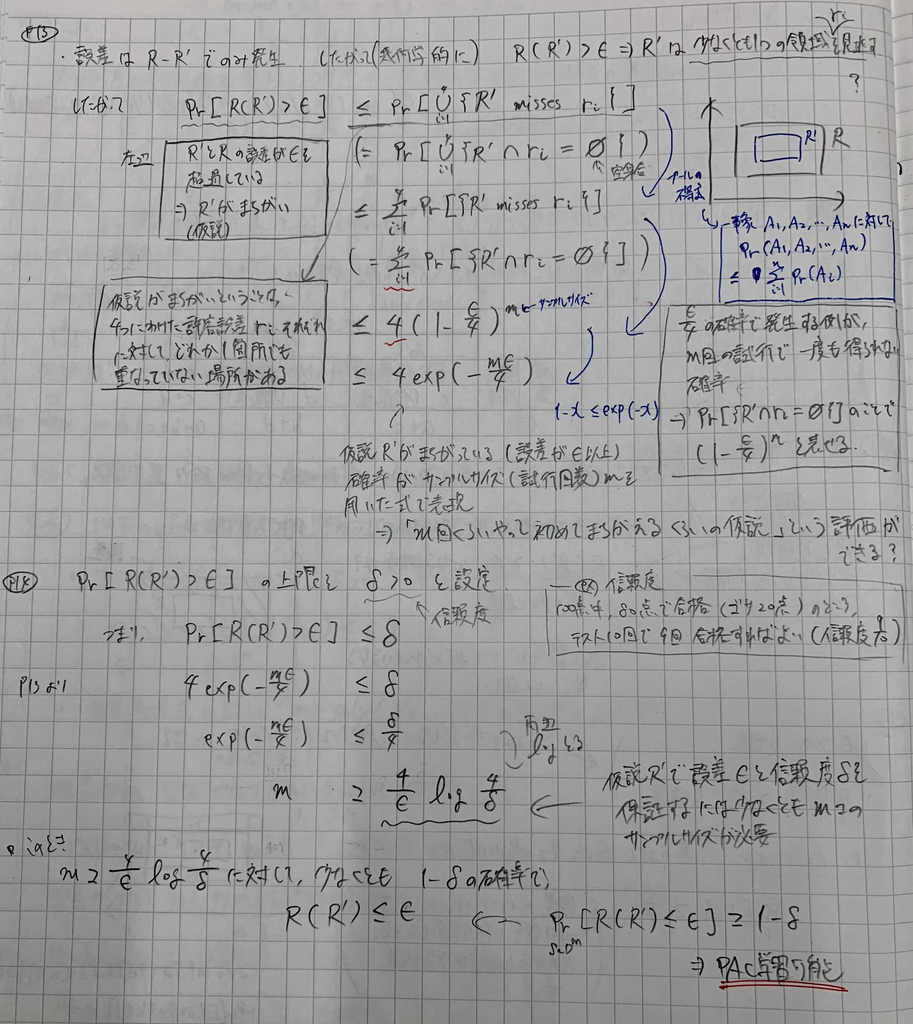

## Guarantees for finite hypothesis sets — consistent case

### Theorem 2.5 (Learning bound — finite H, consistent case)

- $\mathcal{H}$を$\mathcal{X}$から$\mathcal{Y}(\{0,1\})$に写像する関数の有限集合とする
- $\mathcal{A}$は、任意のターゲット概念$c \in \mathcal{H}$とi.i.d.標本$S$に対して、一貫性のある仮説$h_S$($\hat{R}_S(h_S) = 0$)を返すアルゴリズムとする
- 任意の$\delta > 0$に対して、少なくとも$1-\delta$の確率で

$$R(h_S) \leq \frac{1}{m}(log|\mathcal{H}| + log \frac{1}{\delta}) \tag{2.9}$$

### proof

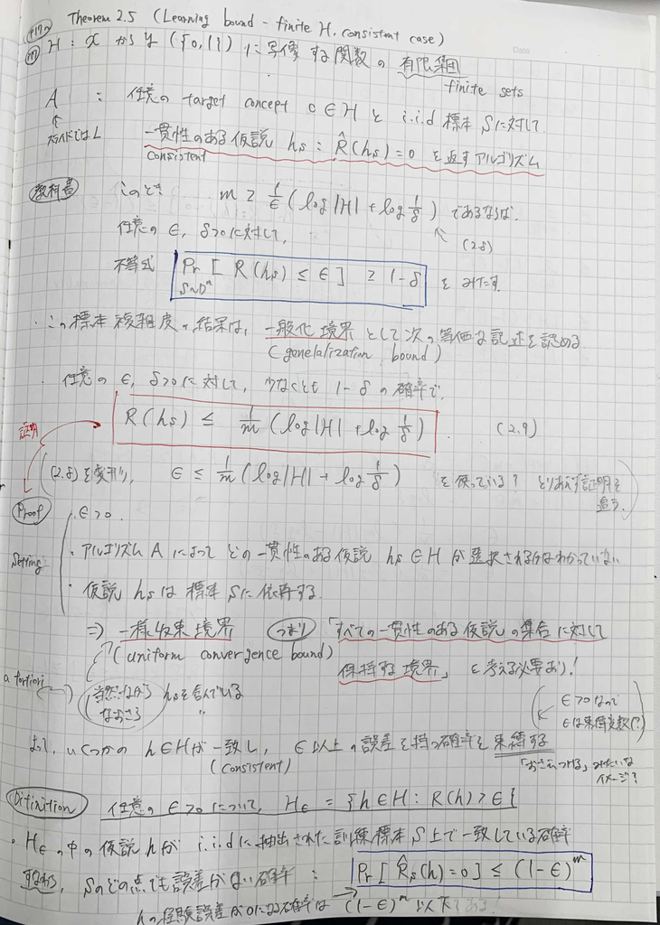

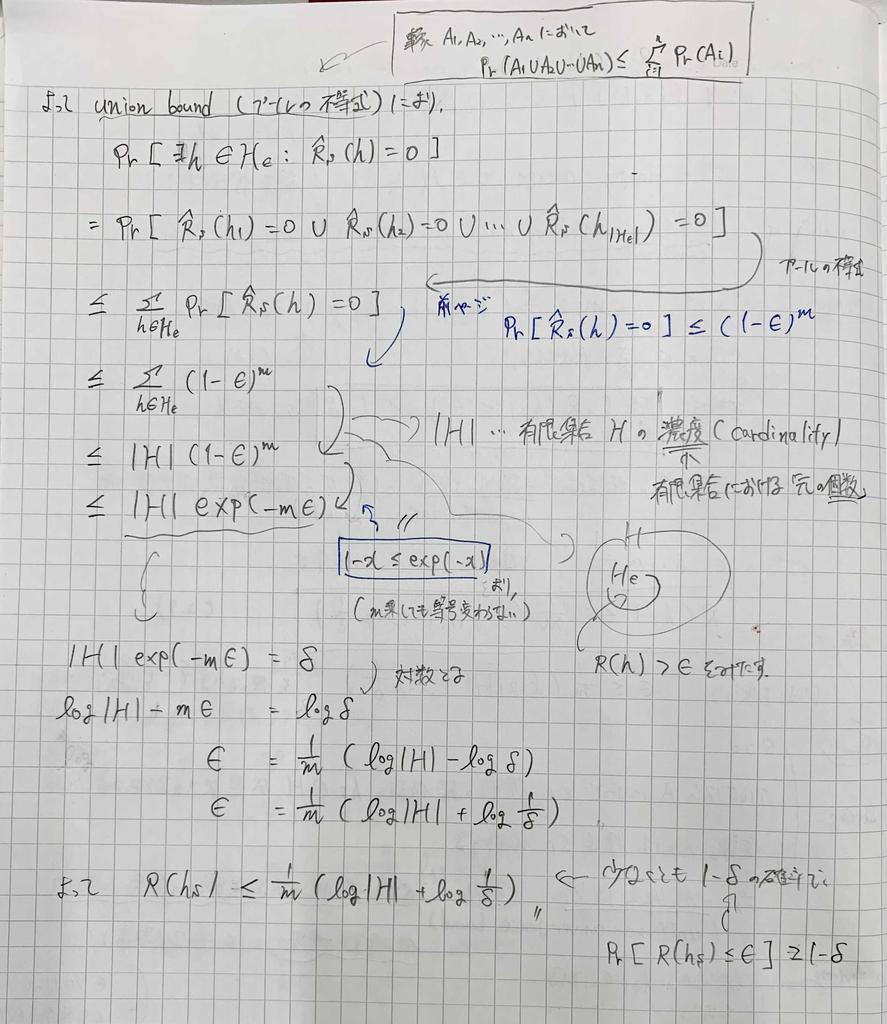

### Example 2.6 (Conjunction of Boolean literals)

Boolean : true or falseの型 (java?)  
literals: 定数値

以下では、Boolean literalsを「ブール値」と訳す

- 最大n個のブール値 $x_1, ... , x_n$ の論理積の概念クラス$\mathcal{C}_n$を学習することを考える
  - ブール値は、変数 $x_i, \; i ∈[n]$、またはその否定 $\bar{x}_i$ のいずれか
- 例1）n = 4
  - 論理積 $x_1∧ \bar{x}_2∧ x_4$ があり、ここで $\bar{x}_2$ はブール値 $x_2$ の否定を表す
  - (1, 0, 0, 1) はこの概念の正の例
  - (1, 0, 0, 0) はこの概念の負の例
- 例2）n = 4
  - 正の例 (1, 0, 1, 0) は、ターゲット概念が定数値 $\bar{x}_1$ と $\bar{x}_3$ を含むことができず、定数値 $x_2$ と $x_4$ を含むことができないことを意味する
  - 対照的に、負の例 (例えば(1,0,0,0)) はそのnビットのうちのどのビットが正しくないかがわからないため、情報量が少なくなる
- よって一貫性のある仮説を見つけるための簡単なアルゴリズムは、正の例に基づいており、次のように構成されています。
  - 各正の例 $(b_1, ... , b_n)$ と $i∈[n]$ について、  
    $b_i=1$ならば、$x_i$は概念クラスの可能性のある定数値とされ、  
    $b_i=0$ならば、$x_i$は除外される
  - 除外されていないすべての定数値の論理積は、ターゲット概念と一致する仮説となる

### Example Figure2.4

- 以下の図2.4は、学習サンプルの例と、n = 6の場合の一貫した仮説を示している

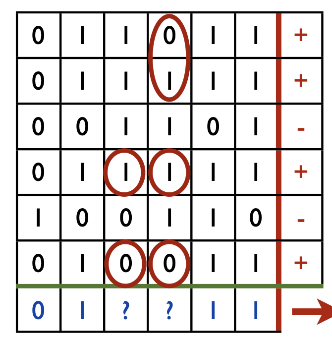

- 図2.4 (n = 6のとき)
  - 表の最初の6行は学習例
  - 最後の列 (7列目) に$+$または$-$のラベル
  - 最後の行 (7行目) は、すべての正の例 (7列目が$+$) に対して、$i$列目の要素が全て0(or1)であれば、$i∈[6]$にそれぞれ0(or1)が入る
  - また、正の例において、0と1の両方が$i$番目の要素として現れる場合 (図中の赤枠) には、最後の行に“?”が入る
  - この学習サンプルについて、一貫性のあるアルゴリズムによって返される仮説は、$\bar{x}_1∧ x_2∧ x_5∧ x_6$

### Algorithm

- 各ブール値は正に含まれていても、否定されていても、含まれていなくてもよいので、  
  $|\mathcal{H}| =|\mathcal{C}n| = 3^n$となる
- 一貫性のある仮説の標本複雑度境界(式2.8)に当てはめると、任意の $\epsilon > 0$ および $\delta > 0$ において、  
  以下のような標本複雑度境界が得られる

$$m \geq \frac{1}{\epsilon}\bigl( (log3)n \:+\: log\frac{1}{\delta} \bigr) \tag{2.10}$$

- したがって，最大n個のブール値の論理積のクラスはPAC-learnableである
  - (2.10)を満たすならば、仮説 $h_S$ は任意の $\epsilon,\delta > 0$ に対して、$Pr_{S \sim D^m}[R(h_s) \leq \epsilon] \geq 1 - \delta$ を満たす。すなわちPAC-learnablである。
- $δ = 0.02、\epsilon = 0.1、n = 10$の場合、境界は$m \geq 149$となる
  - 少なくとも149個の例のラベル付きサンプルでは、この境界は、少なくとも98%の信頼度で90%の精度を保証

## Guarantees for finite hypothesis sets — inconsistent case

### Corollary 2.10

Corollary: ある主張（典型的には定理）の系（けい、英: corollary）とは、その（既知の）主張から「直ちに」証明される主張をいう (Wikipediaより引用)

- $\epsilon>0$ とすると、任意の仮説 $h : X → \{0, 1\}$ に対して，次の不等式が成立する

$$Pr_{S \sim D^m}[\hat{R}_S(h)-R(h) \geq \epsilon] \leq exp(-2m\epsilon^2) \tag{2.14}$$
$$Pr_{S \sim D^m}[\hat{R}_S(h)-R(h) \leq -\epsilon] \leq exp(-2m\epsilon^2) \tag{2.15}$$

- プールの不等式により、以下のような両面不等式を意味する

$$Pr_{S \sim D^m}[|\hat{R}_S(h)-R(h)| \geq \epsilon] \leq 2exp(-2m\epsilon^2) \tag{2.16}$$
### proof

- この結果は定理D.2からすぐに従う
- (2.16)の右辺を$δ$とおいて$\epsilon$について解くと，一つの仮説に対してすぐに次のような境界が得られる

### Corollary 2.11 (Generalization bound — single hypothesis)

系 2.11 (一般化境界-単一仮説)

- 仮説 h をX → {0, 1}とすると、任意の$δ＞0$に対して、以下の不等式が少なくとも$1 - δ$の確率で成り立つ

$$R(h) \leq \hat{R}_S(h) \:+\: \sqrt{\frac{log2/\delta}{2m}} \tag{2.17}$$

### Example 2.12 (Tossing a coin)

- 偏ったコインを投げて、確率$p$で表が出ると想像
  - 我々の仮説:常に裏を推測するものとする
- 真の誤差確率は$R(h) = p$、経験誤差確率は$\hat{R}_S(h) = \hat{p}$
  - ここで$\hat{p}$はi.i.dに抽出された学習サンプルに基づいた、表が出る経験的な確率
- このように，系2.11は，少なくとも$1 - δ$ の確率で，以下を保証する

$$|p-\hat{p}| \leq \sqrt{\frac{log2/\delta}{2m}} \tag{2.18}$$

- したがって、$δ＝0.02$とし、大きさ$m=500$の標本を用いた場合、98％以上の確率で、次のような近似が保証される

$$|p-\hat{p}| \leq \sqrt{\frac{log2(10)}{1000}} \approx 0.048 \tag{2.19}$$